# Тестирование статистических гипотез

Линейные модели…

Наталья Арбузова, Вадим Хайтов, Валентина Домашкина, Анастасия Лянгузова, Юта Тамберг, Марина Варфоломеева

Кафедра Зоологии беспозвоночных, СПбГУ

## Тестирование гипотез

- Выборочное распределение среднего значения
- Как устроено тестирование гипотез
- t-статистика
- Применение t-теста
- Статистическая значимость

# Оценка параметров распределения по выборке

## Задание

- Загрузите объект `population`. Это вектор, характеризующий размеры особей в некоторой гипотетической популяции.

```r
load("data/population.RData")
```

- Сделайте из этой совокупности случайную выборку в 5 измерений.

```r
my_sample <-  sample(x = population, size = 5)

my_sample
```

```
[1] 171.6 161.0 166.0 161.7 170.7
```

- Определите среднее значение и среднеквадратичное отклонение.

```r
mean(my_sample)
```

```
[1] 166.2
```

```r
sd(my_sample)
```

```
[1] 4.918
```

- Проведите такую выборку несколько раз.

## Выборочные оценки

- Изучая интересующую нас систему, мы не знаем значений параметров распределения, которое описывает поведение вероятности в **генральной совокупности** (*population*).
- Мы проводим **оценку** (*estimate*) этих параметров, используя **выборку** (*sample*).
- Выборка имеет ограниченный **объем**(*N*, или *n*).
- Выборка попадает в анализ в виде вектора значений $\{x_1, x_2, x_3, \dots , x_n\}$

## Выборочные оценки

Выборка может быть описана с помощью “5 number statistic”:

- Min
- Q1
- Q2 (Median)
- Q3
- Max

## Выборочные оценки

Другой способ описания выборки

- Среднее значение: $\bar{x}=\frac{\Sigma{x_i} }{n}$
- Стандартное отклонение: $sd = \sqrt{\frac{\Sigma{(x_i - \bar{x})^2}}{n-1} }$

Если $x_i \in N(\mu, \sigma)$, то

$$\bar{x} \xrightarrow[n\to\infty]{} \mu$$

$$sd \xrightarrow[n\to\infty]{} \sigma$$

# Выборочная оценка среднего

## Как можно судить о свойствах генеральной совокупности по выборке?

**Центральная предельная теорема** (ЦПТ) говорит, что если мы возьмем достаточно большую выборку из генеральной совокупности, то среднее значение будет нормально распределено с параметрами $\mu_{\bar x}$ и $\sigma _{\bar{x}}$:

$$\bar X \sim N (\mu_{\bar x}, \sigma_{\bar x})$$

При чем $\sigma_{\bar x} = \frac{\sigma}{\sqrt{n}}$.

**Важно**: это будет так при *больших объемах выборки* ( $n > 30$, или даже $n > 100$), даже если $x$ в генеральной совокупности не подчиняется нормальному распределению.

Давайте проверим на опыте, так ли это.

## Цена алмазов

Представим, что данные об алмазах из датасета `diamonds` (пакет `gplot2`) — это генеральная совокупность.

Перед вами распределение цены алмазов. Давайте будем брать из этого распределения выборки и оценивать по ним среднее значение.

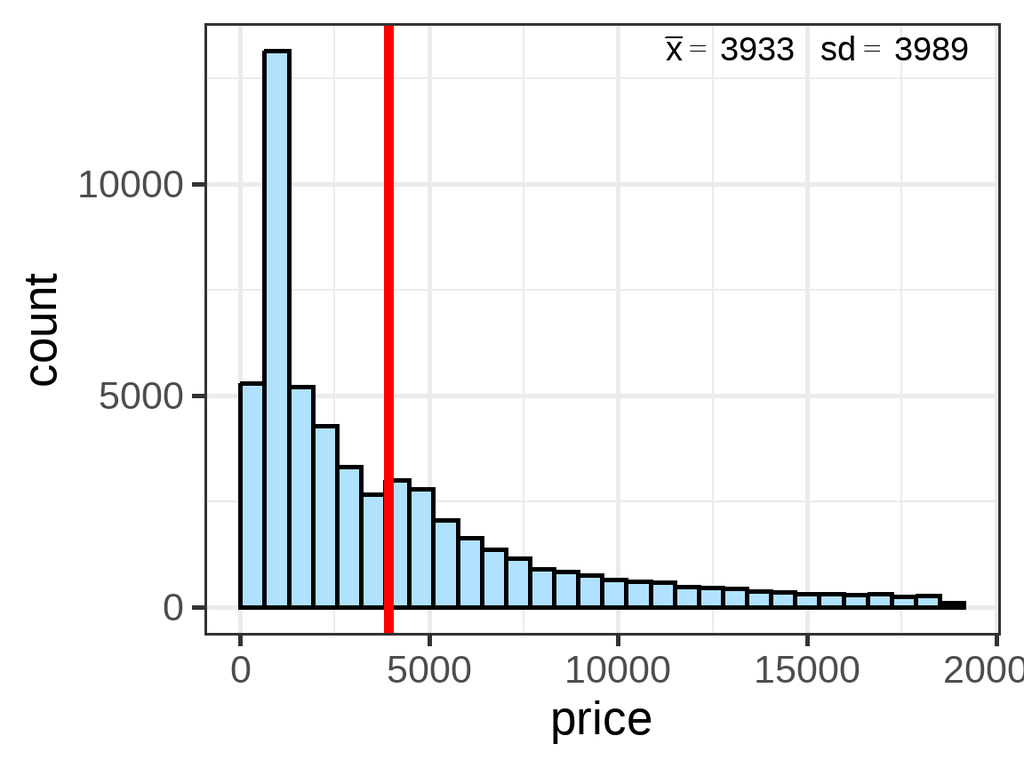

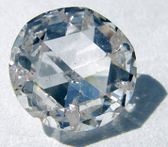

Diamond Age by Steve Jurvetson on Flickr

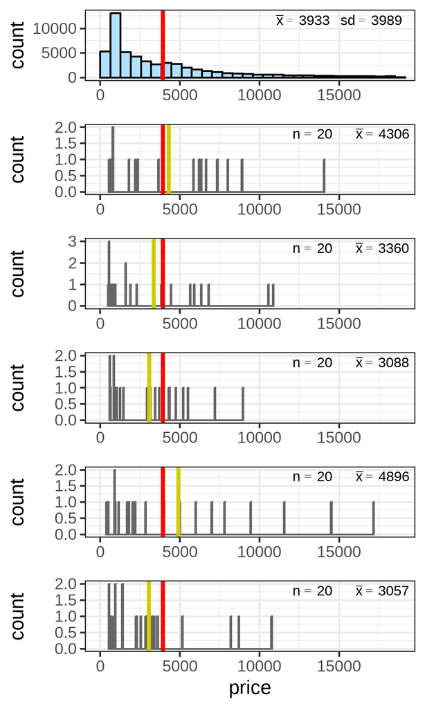

### Средние в выборках

Средние в выборках отличаются от среднего в генеральной совокупности.

Если взять много выборок определенного размера, можно построить распределение выборочных средних.

Как изменится форма распределения выборочных средних при изменении объема выборки?

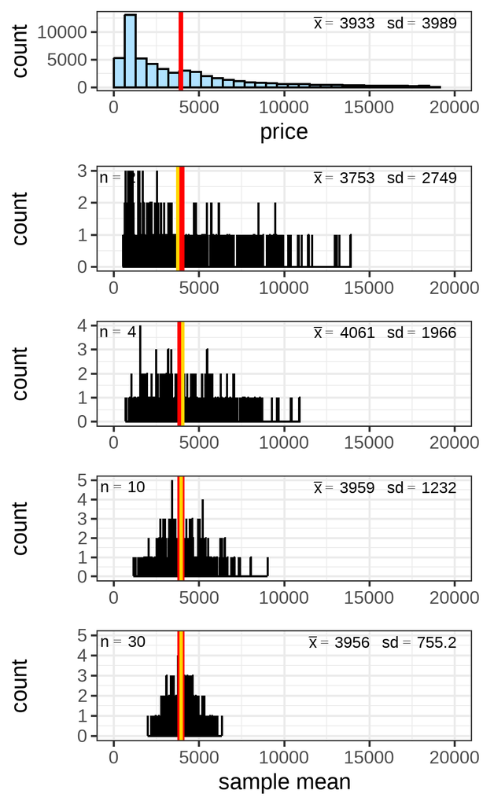

### Распределение выборочных средних при разных объемах выборки

$$\bar X \sim N (\mu_{\bar x}, \sigma_{\bar x})$$

$\mu_{\bar x} = \mu$ — среднее значение выборочных средних стремится к среднему в генеральной совокупности.

$\sigma_{\bar x} = \sigma / \sqrt{n}$ — стандартное отклонение в $\sqrt{n}$ раз меньше стандартного отклонения в генеральной совокупности.

$\sigma_{\bar x}$ называют стандартной ошибкой среднего и обозначают $SE _{\bar{x}}$.

## Центральная предельная теорема очень важна в статистике

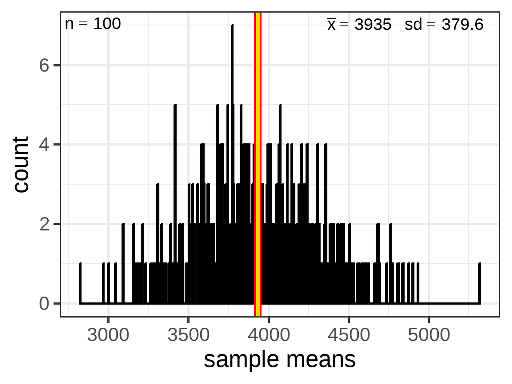

$$\bar X \sim N (\mu, \sigma / \sqrt{n})$$

Пользуясь ее выводами, мы сможем:

- строить доверительные интервалы
- тестировать гипотезы

# Доверительный интервал

## Если выполняется центральная предельная теорема…

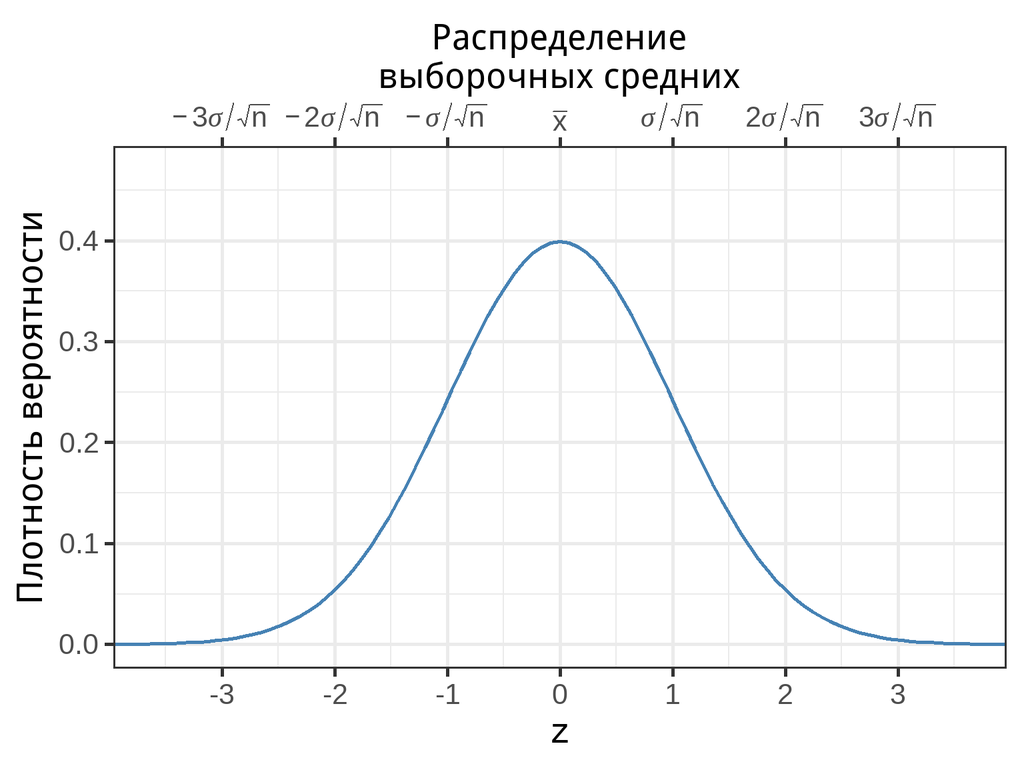

Было

$$\bar X \sim N(\mu, \sigma/ \sqrt{n})$$

После стандартизации:

$$\frac{\bar X - \mu}{\sigma / \sqrt{n}} \sim N(0, 1)$$

Стандартизованное распределение выборочных средних — это стандартное нормальное распределение.

## Доверительный интервал из нормального распределения

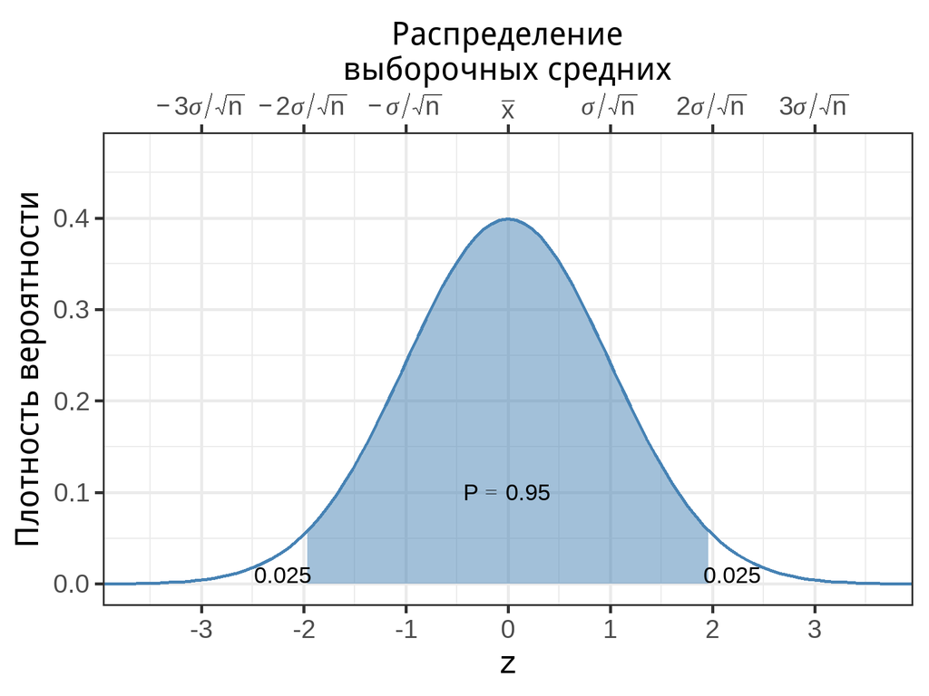

— это интервал, в который попадает заданный процент выборочных средних.

В 95% доверительный интервал попадает выборочное среднее в 95% *повторных* выборок.

Как найти этот интервал?

## Доверительный интервал из нормального распределения

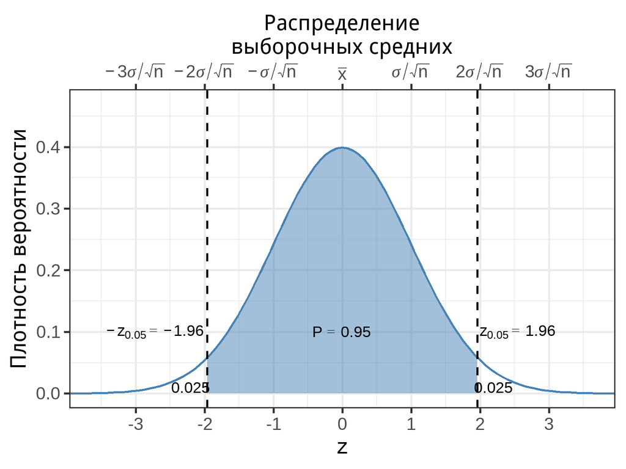

$$\bar {x} \pm z_{\alpha} \cdot \sigma / \sqrt{n}$$

Чтобы найти границы 95% доверительного интервала, нужно найти квантили стандартного нормального распределения, которые соответствуют вероятностям 0.025 и 0.975

```r
qnorm(p = c(0.025, 0.975))
```

```
[1] -1.96  1.96
```

$z_{0.05} = 1.96$

95% выборочных средних в повторных выборках будут лежать в пределах $\pm 1.96$ стандартных ошибок вокруг среднего значения.

## Условия применимости нормального распределения для доверительного интервала

1.Должна быть известна $\sigma$ в генеральной совокупности.

2.Должны выполняться условия, при которых справедлива ЦПТ:

- Наблюдения в выборке должны быть независимы друг от друга.
- Большой объем выборки **или** нормальное распределение $x$

## Если $\pmb \sigma$ не известна

Если $\sigma$ в генеральной совокупности не известна, ее можно оценить по выборочному стандартному отклонению $sd$.

$$\sigma / \sqrt{n} \approx sd/\sqrt{n}$$

После стандартизации:

$$\frac{\bar X - \mu}{SE_{\bar x}} = \frac{\bar X - \mu}{sd / \sqrt{n}} \sim t_{df = n - 1}$$

стандартизованное распределение выборочных средних подчиняется $t$-распределению с числом степеней свободы $df = n - 1$

## *t*-распределение, или распределение Стьюдента

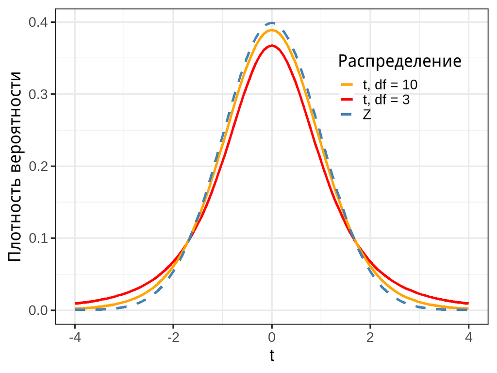

- Симметричное колоколообразное распределение с толстыми хвостами.
- Единственный параметр — число степеней свободы (для доверительного интервала $df = n - 1$).
- При увеличении объема выборки $t$-распределение приближается к нормальному.

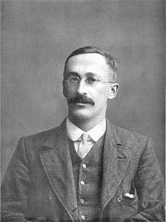

William Sealy Gosset

## Доверительный интервал из *t*-распределения

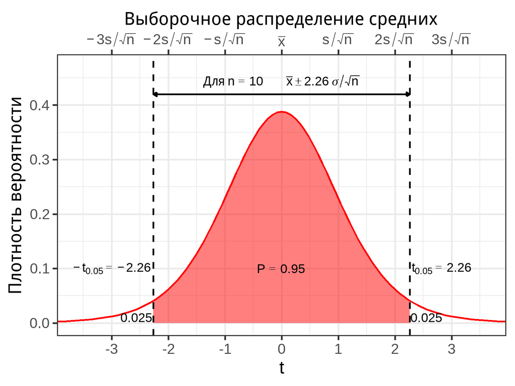

Обязательно используется, если:

- Объем выборки мал.
- $\sigma$ не известна.

$$\bar {x} \pm t_{\alpha, df} \cdot sd / \sqrt{n}$$

$df = n - 1$

Условия применимости

Выполняются условия, при которых справедлива ЦПТ:

- Наблюдения в выборке независимы друг от друга.
- Большой объем выборки и нет “выбросов” **или** нормальное распределение $x$

## Смысл 95% доверительного интервала

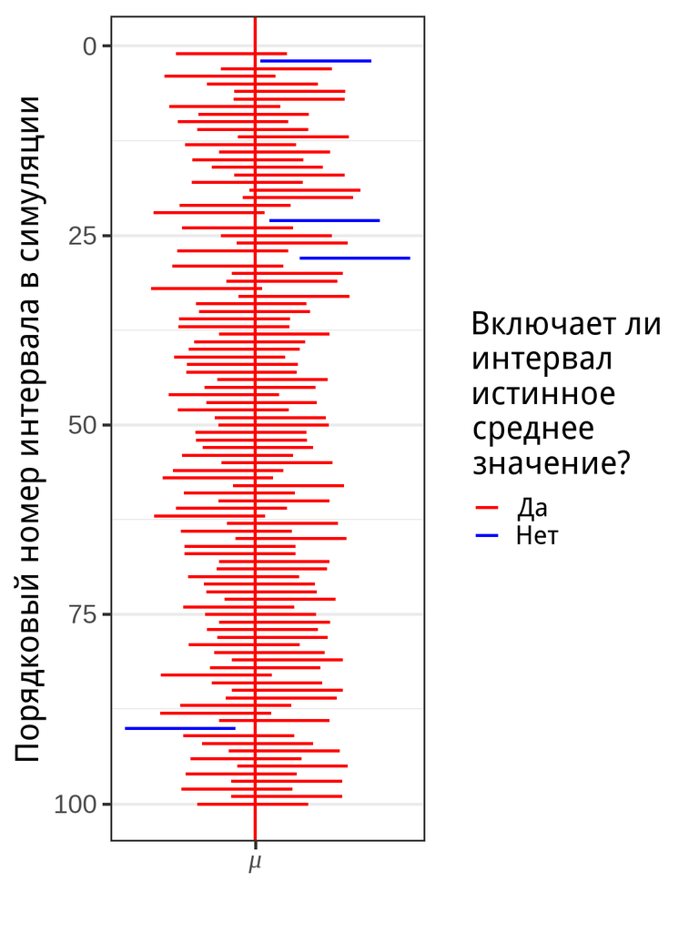

- Для примера возьмем данные из объекта `population`. Здесь известно, что $\mu = 170$.
- Симулируем взятие многих выборок из этой генеральной совокупности.
- Среднее в генеральной совокупности — это фиксированная величина (она либо попала в интервал, либо нет.
- Доверительный интервал — случайная величина.
- В *повторных выборках* одинакового объема $\approx 95\%$ всех доверительных интервалов “накроют” истинное среднее значение.

## Расчет и изображение доверительного интервала в R

```r
library(ggplot2)
data("diamonds")

# цена бриллиантов хорошего качества огранки
good <- diamonds$price[diamonds$cut == "Good"]

.mean <- mean(good)                  # выборочное среднее
.n <- length(good)                   # объем выборки
SE <- sd(good)/ sqrt(.n)             # стандартная ошибка
t_crit <- qt(p = 0.975, df = .n - 1) # критич. зн. t для данного n и p = 0.95
err <- t_crit * SE                   # величина размаха доверительного интервала
err
```

```
[1] 103
```

```r
# Границы доверительного интервала
.mean - err
```

```
[1] 3826
```

```r
.mean + err
```

```
[1] 4032
```

Можем записать среднюю цену бриллиантов хорошей огранки и ее доверительный интервал: $3928.9 \pm 103 (\pm SE \cdot t_{\alpha, df})$

## Строим доверительные интервалы в ggplot

```r
## theme_set(theme_bw())
ggplot(data = diamonds, aes(x = cut, y = price)) +
  stat_summary(geom = 'pointrange', fun.data = mean_cl_normal)
```

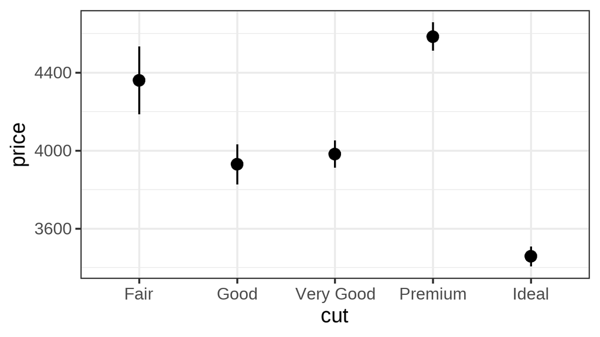

## Задание 1

Посчитайте среднюю цену и доверительный интервал для бриллиантов с такими свойствами (*одновременно*):

- качество огранки (`cut`) идеальное (`Ideal`)
- прозрачность (`clarity`) наивысшая (`IF`)

Постройте график средней цены с доверительными интервалами для бриллиантов разного качества огранки и прозрачности.

## Решение

Вычислим границы доверительного интервала

```r
ideal <- diamonds$price[diamonds$cut == 'Ideal' & diamonds$clarity == 'IF']

.mean <- mean(ideal)                  # выборочное среднее
.n <- length(ideal)                   # объем выборки, если нет NA
SE <- sd(ideal)/ sqrt(.n)             # стандартная ошибка
t_crit <- qt(p = 0.975, df = .n - 1) # критич. зн. t для данного n и p = 0.95
err <- t_crit * SE                   # величина размаха доверительного интервала
err
```

```
[1] 187.1
```

```r
# Границы доверительного интервала
.mean - err
```

```
[1] 2086
```

```r
.mean + err
```

```
[1] 2460
```

## Решение: cпособ 1 (некрасивый, требует доработки)

Теперь можно построить график средней цены с доверительными интервалами для бриллиантов разного качества огранки и прозрачности. Для этого нужно к предыдущему графику добавить информацию о прозрачности.

```r
ggplot(data = diamonds, aes(x = cut, y = price, colour = clarity)) +
  stat_summary(geom = 'pointrange', fun.data = mean_cl_normal)
```

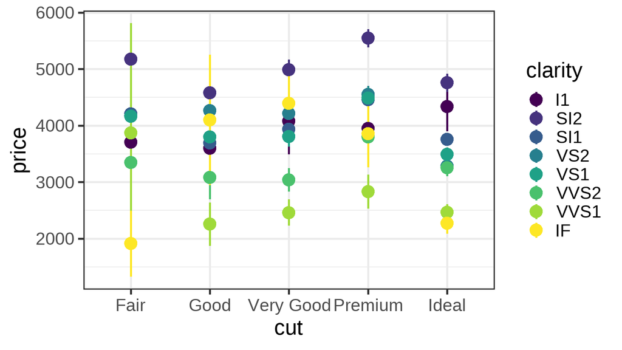

## Решение: cпособ 1 (доработка)

Теперь можно построить график средней цены с доверительными интервалами для бриллиантов разного качества огранки и прозрачности. Для этого нужно к предыдущему графику добавить информацию о прозрачности и смещении точек.

```r
ggplot(data = diamonds, aes(x = cut, y = price, colour = clarity)) +
  stat_summary(geom = 'pointrange', fun.data = mean_cl_normal, position = position_dodge(width = 0.5))
```

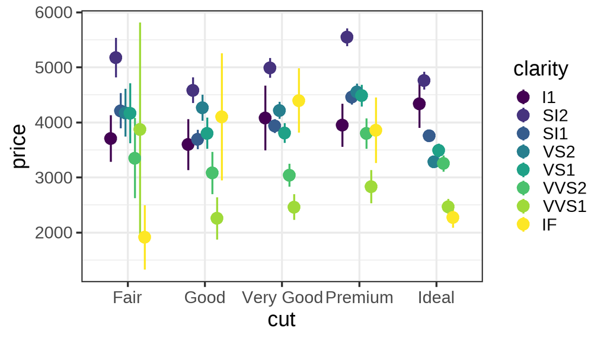

## Решение: cпособ 2 (удовлетворительный)

```r
ggplot(data = diamonds, aes(x = cut, y = price, colour = clarity)) +
  stat_summary(geom = 'pointrange', fun.data = mean_cl_normal) +
  facet_wrap(~ clarity) +
  theme(axis.text.x = element_text(angle = 45, hjust = 1))
```

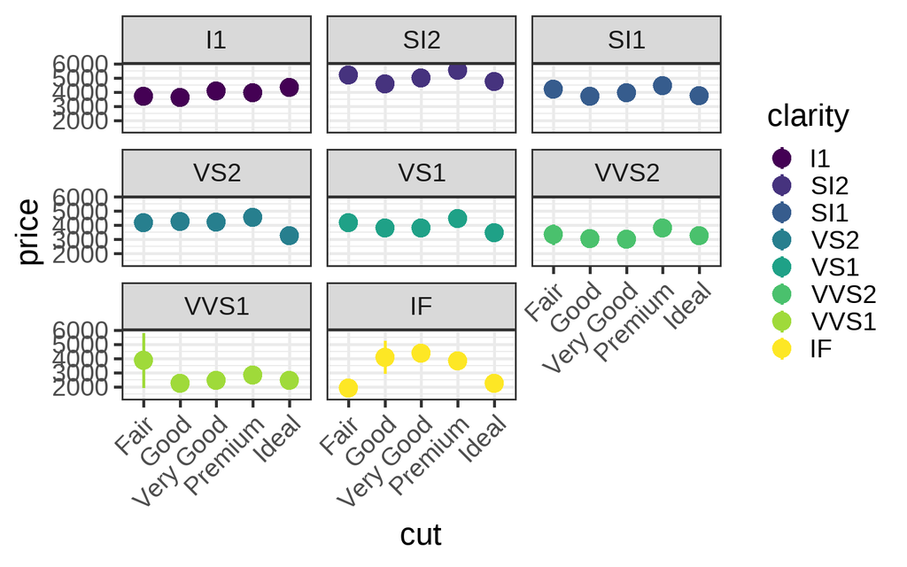

Что странного в этой картинке?

Осторожно! Группы могут быть неоднородны: в каждой группе варьирует размер алмазов.

## Статистика по группам при помощи пакета `dplyr`

На примере доверительных интервалов:

```r
library(dplyr)

smr_diamonds <- diamonds %>%             # данные
  group_by(cut, clarity) %>%             # группируем
  summarize(
    .mean = mean(price),                 # выборочное среднее
    .n = n(),                            # объем выборки
    SE = sd(price) / sqrt(.n),           # стандартная ошибка
    t_crit = qt(p = 0.975, df = .n - 1), # критич. зн. t
    err = t_crit * SE,                   # величина величина размаха доверительного интервалаа доверительного интервала
    lower = .mean - err,  #  нижняя граница доверительного интервала
    upper = .mean + err   # верхняя граница доверительного интервала
  )

head(smr_diamonds)
```

```
# A tibble: 6 × 9
# Groups:   cut [1]
  cut   clarity .mean    .n    SE t_crit   err lower upper
  <ord> <ord>   <dbl> <int> <dbl>  <dbl> <dbl> <dbl> <dbl>
1 Fair  I1      3704.   210  214.   1.97  422. 3282. 4125.
2 Fair  SI2     5174.   466  182.   1.97  358. 4816. 5531.
3 Fair  SI1     4208.   408  162.   1.97  319. 3889. 4527.
4 Fair  VS2     4175.   261  219.   1.97  431. 3744. 4605.
5 Fair  VS1     4165.   170  276.   1.97  546. 3619. 4711.
6 Fair  VVS2    3350.    69  364.   2.00  727. 2623. 4077.
```

# Как устроено тестирование гипотез

## Сравнение выборок

Различия между выборками не всегда видны невооружённым глазом.

## Нулевая и альтернативная гипотезы

Это первый шаг

- Нулевая гипотеза $H_0$ чаще всего формулируется как **отсутствие различий** между сравниваемыми объектами. Например: Улитки из обеих популяций одинакового размера
- Альтернативная гипотеза $H_A$ формулируется как **присутствие различий**, она обратна нулевой гипотезе, т.е. включает все остальные случаи. Например: Улитки из обеих популяций разного размера.

## Нулевая и альтернативная гипотезы — это “два мира”

Вне зависимости от нас, реальность может находиться в одном из двух состояний:

- $H_0$ верна, улитки одинаковы
- $H_0$ неверна, улитки различаются

После статистического теста мы принимаем решение о том, принять или отвергнуть $H_0$. Но это решение не обязательно окажется верным. Возможно четыре исхода:

В мире где улитки одинаковы  
( $H_0$ верна) мы можем:  
- принять $H_0$ (верное решение),  
- отвергнуть $H_0$ (ошибка).

В мире где улитки различаются  
( $H_A$ верна), мы можем:  
- принять $H_0$ (ошибка),  
- либо отвергнуть $H_0$ (верное решение).

## Верные и неверные решения

**Ошибка I рода: нашли то, чего нет**

**Ошибка II рода: не нашли то, что было**

|  | $H_0$ верна | $H_0$ неверна |
| --- | --- | --- |
| Отклонить H0 | Ошибка **I рода** с вероятностью α Ложно-положительный результат | Верно |
| Сохранить H0 | Верно | Ошибка **II рода** с вероятностью β Ложно-отрицательный результат |

Пока мы будем говорить о том, как контролируют уровень **Ошибок I рода**. Про **Ошибки II рода** и **Power analysis** читайте дополнительную литературу.

## Тестирование гипотез: Тестовые статистики

#### 1. Формулируем нулевую и альтернативную гипотезы.

Гипотезы выражаются математически в виде тестовых статистик. На этом этапе мы делаем определенные допущения.

#### 2. Проверяем **условия применимости** тестовой статистики.

#### 3. По реальным данным вычисляем **эмпирическое значение тестовой статистики**.

Дальше мы должны ответить на вопрос:

**Насколько вероятно получить *такое или более экстремальное* эмпирическое значение, если верна нулевая гипотеза $H_0$?**

#### 4. Строим теоретическое распределение тестовой статистики для случая, когда верна $H_0$, и оцениваем по нему уровень значимости.

#### 5. Решаем сохранить или отвергнуть $H_0$.

Увы, мы не сможем узнать, какая гипотеза верна, но поймем, насколько с ней согласуются исходные данные.

# Одновыборочный *t*-тест

## Размер кладки черепах

Разберемся с одновыборочным $t$-тестом на вымышленном примере.

Представьте, что в [одной статье](https://edis.ifas.ufl.edu/publication/UW441#:~:text=Reproductive%20rate%3A%20Clutch%20sizes%20range,to%20100%20years%20in%20captivity.) сказано, что средняя плодовитость черепах определенного вида — 8 яиц в кладке.

В вашей выборке из $35$ черепах — $\bar x = 9$, $sd = 2$.

Отличается ли приведенное в статье значение от того, что наблюдается в изученной популяции. Можно ли считать, что авторы статьи изучали что-то иное (другой вид, или популяцию из иных условий).

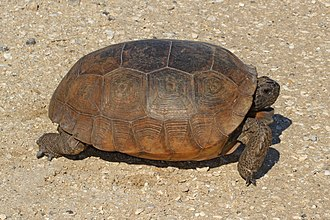

Gopher Tortoise by Judy Gallagher on Flickr

## Одновыборочный t-тест

- $H_0: \mu = \mu_0$ — Реальная средняя плодовитость черепах такая, как в статье.
- $H_A: \mu \ne \mu_0$ — Средняя плодовитость отличается от того, что написано в статье.

$\mu_0$ — это какое-то конкретное значение. В нашей задаче это — 8 яиц в кладке.

$$t = \cfrac{\bar x - \mu}{ sd / \sqrt{n} }$$

Если выполняется ЦПТ, то одновыборочная $t$-статистика подчиняется $t$-распределению с числом степеней свободы $df = n - 1$.

Условия применимости:

- Наблюдения в выборке должны быть независимы друг от друга.
- Объем выборки достаточно велик **или** величины нормально распределены.

### Задание 2

Проверьте условия применимости t-теста. Вычислите t и p.

## Проверяем, нормально ли распределение

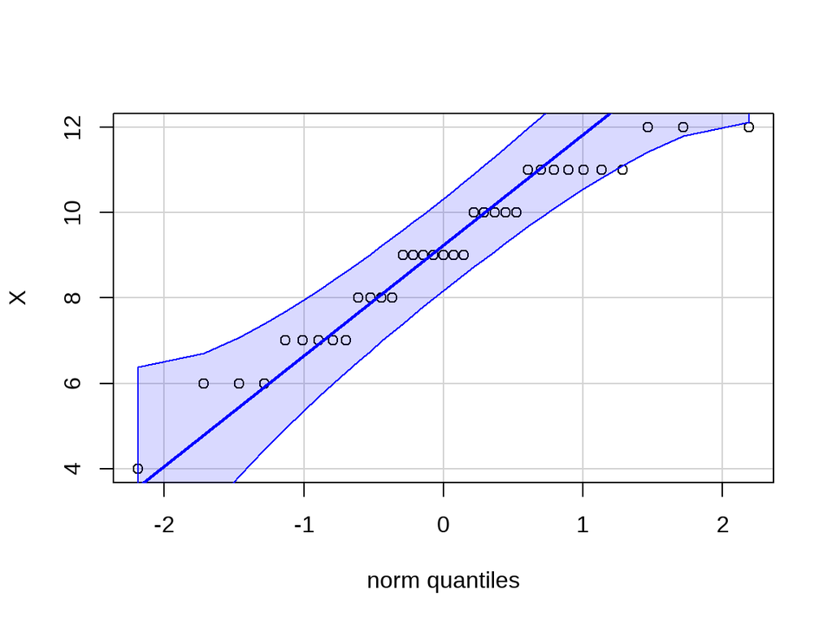

## Вычислим наблюдаемое значение *t*-статистики

$$t = \cfrac{\bar x - \mu}{ sd / \sqrt{n} }$$
Средняя плодовитость в выборке из 35 черепах $\bar x = 9$, стандартное отклонение $s = 2$. В статье указана плодовитость $8$.

$$t = \cfrac{9 - 8}{ 2 / \sqrt{35} } = 2.96$$

## Насколько это значение согласуется с $H_0$?

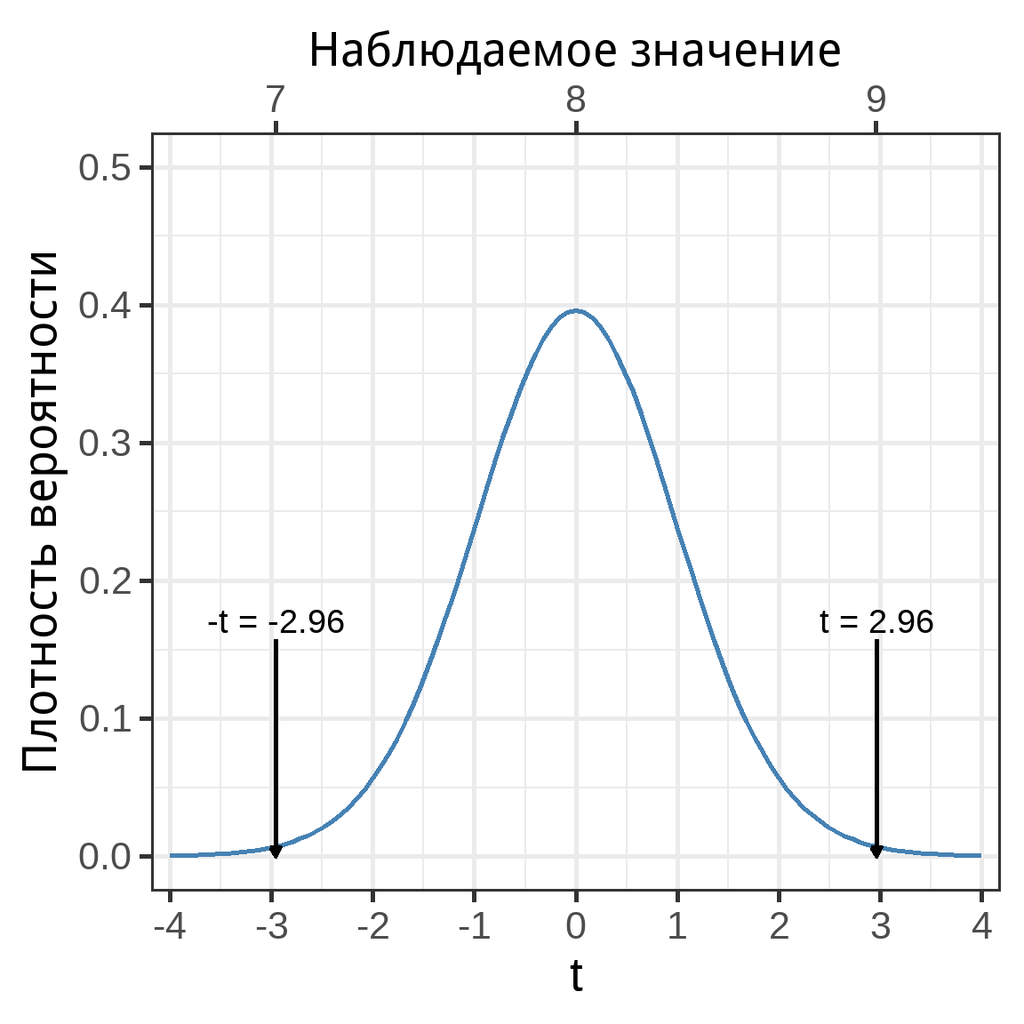

При $H_0$ значение $t$ будет близко к нулю.

Насколько необычны значения t меньше или больше $\pm 2.96$?

## Уровень значимости (*p*-value)

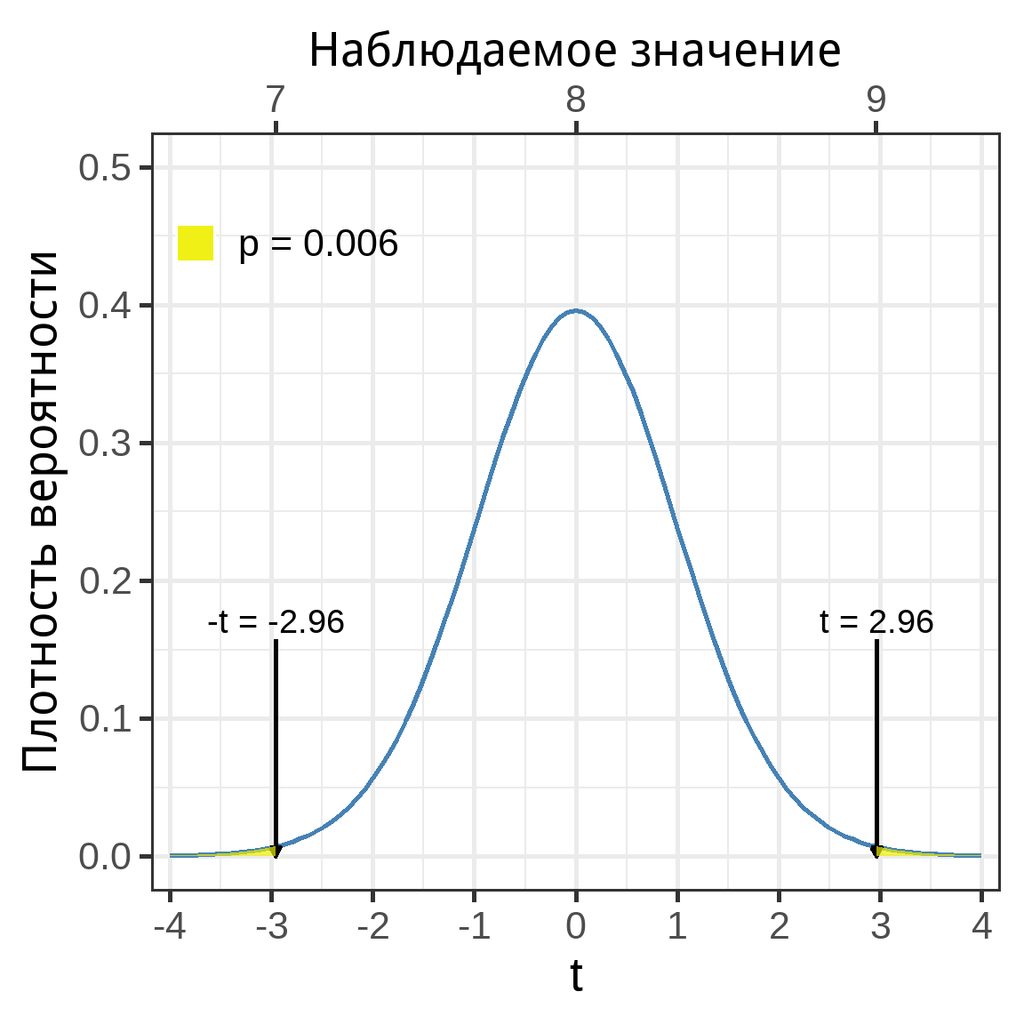

**Уровень значимости** — это вероятность получить значение $t$ меньше или больше данного, если бы $H_0$ была справедлива.

## Уровень значимости (*p*-value)

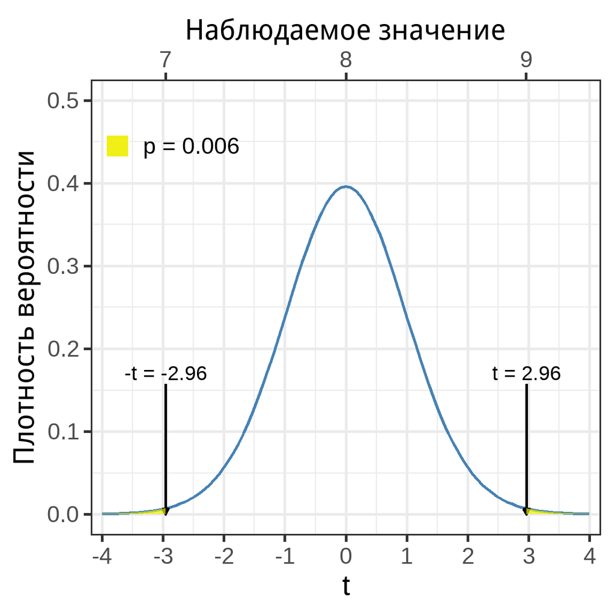

Можно вычислить значение $p$

```r
2 * ( 1 - pt(2.96, df = 35 - 1) )
```

```
[1] 0.005571
```

Если бы плодовитость не отличалось от указанной в статье, получить $t$ меньше или больше $2.96$ можно было бы с вероятностью $p = 0.006$.

## Критический уровень значимости

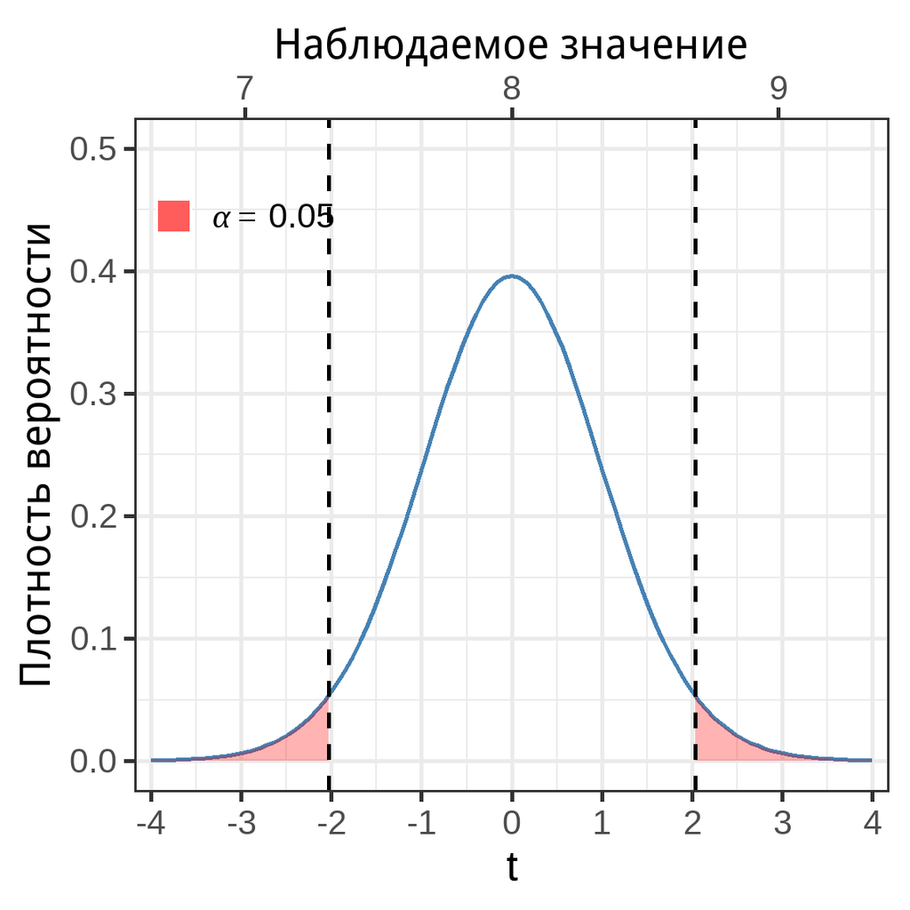

Критический уровень значимости $\alpha$ — это порог для принятия решений.

Обычно используют $\alpha = 0.05$.

$\alpha$ - это допустимая вероятность **Ошибки I рода** (найти отличия там, где их нет).

Если $p \le \alpha$ — отвергаем $H_0$ и принимаем $H_A$.

Если $p > \alpha$ — сохраняем $H_0$, не можем ее отвергнуть.

## Принимаем решение

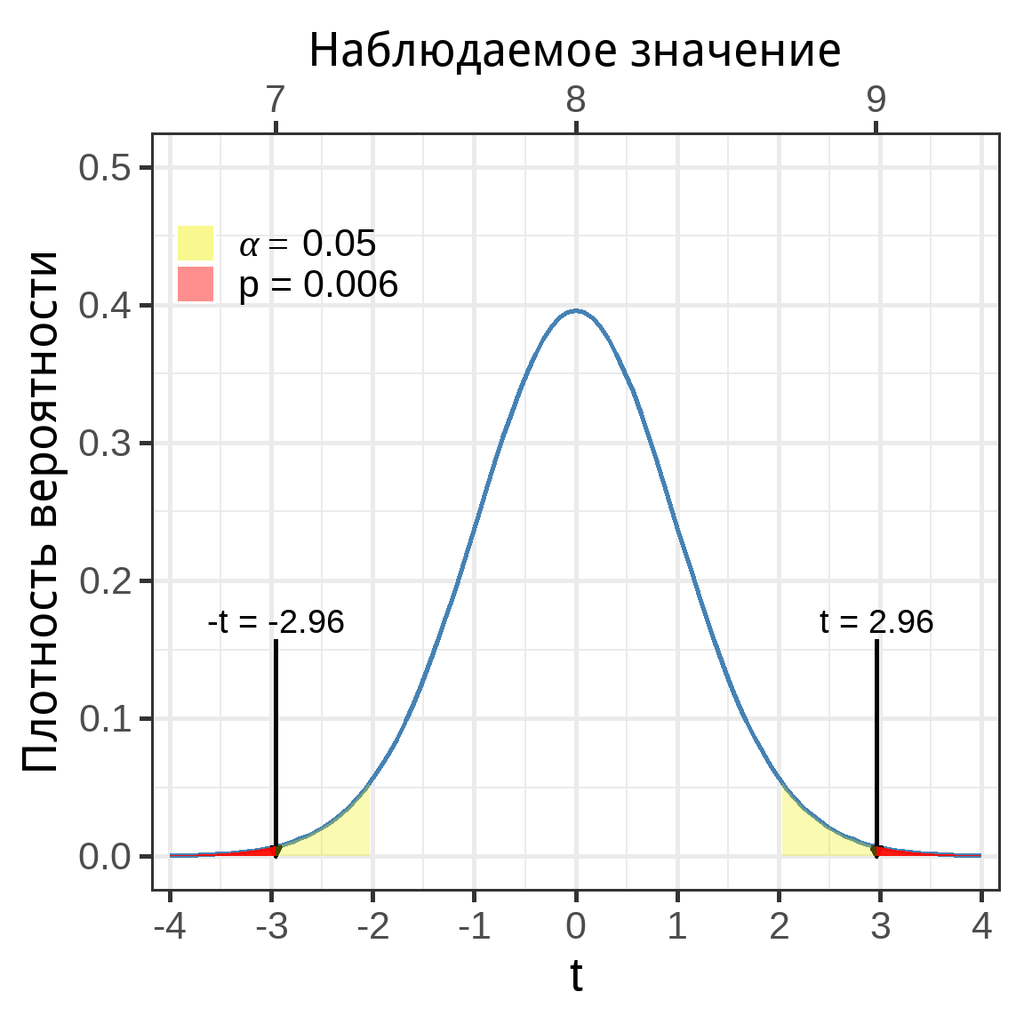

Мы получили $p < \alpha$, поэтому отвергаем $H_0$ и принимаем $H_A$.

Указанная в статье плодовитость **статистически значимо** отличается от плодовитости в изученной нами популяции. Мы изучали что-то иное (другую генеральную совокупность)!

**At!** Лучше не использовать популярное словосочетание “*достоверно отличается*”.

Достоверные события — это события, вероятность которых равна 1.

## Заблуждения о *p*-values

Правда ли, что $p$ — вероятность того, что верна сама $H_0$?

- Нет! Значение $p$ всегда считается **при условии, что $H_0$ верна**. Но $H_0$ может быть неверна.

Правда ли, что $p$ — это вероятность получить такое значение статистики при справедливой $H_0$?

- Нет! Вероятность вычисляется как площадь под участком кривой. Конкретное значение статистики — это точка и под ней нет площади.

Правда ли, что если $p > 0.05$, то различий между группами на самом деле нет?

- Нет! Это значит, что имеющиеся данные не позволяют отвергнуть нулевую гипотезу. Различия могут быть.

*p*-value — это всего лишь вероятность того, что **в мире, где справедлива $H_0$,** при повторных выборках из той же генеральной совокупности значение выбранной статистики (например *t*) будет больше или равно наблюдаемого в нашей выборке.

# Двухвыборочный t-тест

## Гипотезы в двухвыборочном $t$-тесте и тестовая статистика

$H_0: \mu_1 - \mu_2 = 0$ — средние значения не различаются в двух группах

$H_A: \mu_1 - \mu_2 \ne 0$ — средние значения различаются

Т.е. нас интересует **разность выборочных средних**.

Ее ожидаемое значение при $H_0$ будет 0.

t-тест в общем виде выглядит так

$$t=\frac{\text{Наблюдаемая величина - Ожидаемое значение}}{\text{Стандартная ошибка}}$$

## t-тест и его разновидности

Двухвыборочный t-тест используется для проверки значимости различий между средними

$$t\;= \;\frac{\bar{x}_1 - \bar{x}_2}{SE_{\bar{x}_1 - \bar{x}_2}}$$

$SE_{\bar{x}_1 - \bar{x}_2}$ — стандартная ошибка разности двух средних, может рассчитываться по-разному

- t-тест Стьюдента — если считать, что дисперсии в группах равны
- t-тест Уэлча — если считать, что дисперсии могут быть разными

## Стандартная ошибка разности средних в t-тесте Стьюдента

Student 1908

Если группы независимы и дисперсии в них равны, то по центральной предельной теореме

$$SE_{\bar{x}_1 - \bar{x}_2} = \sqrt{ \frac{\sigma^2}{n_{1}} + \frac{\sigma^2}{n_{2}}} \approx \sqrt{ \frac{sd^2}{n_{1}} + \frac{sd^2}{n_{2}}}$$

$s^2 = \cfrac{(n_1 - 1)sd^2_1 + (n_2 - 1)sd^2_2}{n_1 + n_2 - 2}$ — это **обобщенная дисперсия** по двум выборкам.

Результирующая $t$-статистика

$$t\;= \;\frac{\bar{x}_1 - \bar{x}_2}{\sqrt{SE_1^2 + SE_2^2}}$$

подчиняется $t$-распределению с $df = n_1 + n_2 - 2$.

Осторожно, равенство дисперсий в группах — это часто нереалистичное предположение!

## Cтандартная ошибка разности средних в t-тесте Уэлча

Если группы независимы и дисперсии в них неизвестны, то получается

$$SE_{\bar{x}_1 - \bar{x}_2} = \sqrt{ \frac{\sigma^2_{1}}{n_{1}} + \frac{\sigma^2_{2}}{n_{2}}} \approx \sqrt{ \frac{sd^2_{1}}{n_{1}} + \frac{sd^2_{2}}{n_{2}}}$$

Проблема в том, что эта величина **лишь приблизительно следует t-распределению**, если считать его степени свободы как обычно для двух групп $df = n_1 + n_2 - 2$.

## Приблизительное число степеней свободы

Можно рассчитать по уравнению Уэлча-Саттеруэйта. Это решит проблему.

$$df_{ Welch-Satterthwaite} \approx \cfrac {\bigg(\cfrac{sd^2_{1}}{n_{1}} + \cfrac{sd^2_{2}}{n_{2}}\bigg)^2}
{\cfrac{1}{n_{1} - 1}\bigg(\cfrac {sd_{1}^2} {n_{1}}\bigg)^2 + \cfrac{1}{n_{2} - 1}\bigg(\cfrac {sd_{2}^2} {n_{2}}\bigg)^2}$$

t-тестом Уэлча можно пользоваться, даже если дисперсии равны (это более общее решение).

Он немного консервативнее, чем тест Стьюдента.

## Условия применимости двухвыборочного t-теста

Почти такие же, как условия справедливости ЦПТ

- Наблюдения независимы друг от друга.
- Выборки независимы друг от друга (новое условие).
- Объем выборки достаточно велик или величины нормально распределены.

# Двухвыборочный t-тест в R

## Пример: Гормоны и артериальная гипертензия

Синдром Кушинга — это нарушения уровня артериального давления, вызванные гиперсекрецией кортизола надпочечниками.

В датасете `Cushings` (пакет `MASS`) записаны данные о секреции двух метаболитов при разных типах синдрома (данные из кн. Aitchison, Dunsmore, 1975).

- `Tetrahydrocortisone` — секреция тетрагидрокортизона с мочой (мг/сут.)
- `Pregnanetriol` — секреция прегнантриола с мочой (мг/сут.)
- `Type` — тип синдрома:
  - `a` — аденома
  - `b` — двусторонняя гиперплазия
  - `c` — карцинома
  - `u` — не известно

Давайте сравним секрецию тетрагидрокортизона при аденоме и двусторонней гиперплазии надпочечников. Различается ли она?

## Открываем данные

```r
library(MASS)
data("Cushings")
```

Все ли правильно открылось?

```r
head(Cushings)
```

```
   Tetrahydrocortisone Pregnanetriol Type
a1                 3.1         11.70    a
a2                 3.0          1.30    a
a3                 1.9          0.10    a
a4                 3.8          0.04    a
a5                 4.1          1.10    a
a6                 1.9          0.40    a
```

```r
str(Cushings)
```

```
'data.frame':   27 obs. of  3 variables:
 $ Tetrahydrocortisone: num  3.1 3 1.9 3.8 4.1 1.9 8.3 3.8 3.9 7.8 ...
 $ Pregnanetriol      : num  11.7 1.3 0.1 0.04 1.1 0.4 1 0.2 0.6 1.2 ...
 $ Type               : Factor w/ 4 levels "a","b","c","u": 1 1 1 1 1 1 2 2 2 2 ...
```

## Знакомимся с данными

Есть ли пропущенные значения?

```r
colSums(is.na(Cushings))
```

```
Tetrahydrocortisone       Pregnanetriol                Type
                  0                   0                   0
```

Каковы объемы выборки в каждой группе?

```r
table(Cushings$Type)
```

```
 a  b  c  u
 6 10  5  6
```

Обратите внимание, объемы выборок **маленькие**.

## Проверяем условия применимости…

1.Наблюдения независимы друг от друга?

- Да, независимы. Это случайная выборка.

2.Выборки независимы друг от друга?

- Да, независимы. В группах разные люди (естественно, т.к. тип синдрома у человека может быть только какой-то один).

3.Объем выборки достаточно велик или величины нормально распределены?

- Объем выборки мал

```r
table(Cushings$Type)
```

```
 a  b  c  u
 6 10  5  6
```

Нужно проверить форму распределения в обеих группах.

## Нормально ли распределены концентрации тетрагидрокортизона в группах?

```r
library(car)
qqPlot(Cushings$Tetrahydrocortisone[Cushings$Type == 'a'])
qqPlot(Cushings$Tetrahydrocortisone[Cushings$Type == 'b'])
```

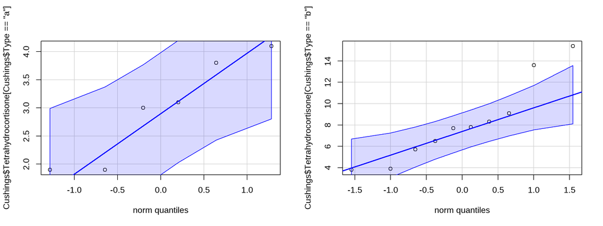

Удовлетворительно. При таких малых объемах выборки сложно ожидать лучшего.

## Двухвыборочный t-тест в R: способ 1.

Сравним секрецию тетрагидрокортизона при помощи **двухвыборочного** t-теста.

```
t.test(x = значения_в_гр.1,
       y = значения_в_гр.2)
```

```r
tt <- t.test(x = Cushings$Tetrahydrocortisone[Cushings$Type == 'a'],
             y = Cushings$Tetrahydrocortisone[Cushings$Type == 'b'])
tt
```

```
    Welch Two Sample t-test

data:  Cushings$Tetrahydrocortisone[Cushings$Type == "a"] and Cushings$Tetrahydrocortisone[Cushings$Type == "b"]
t = -4.1, df = 11, p-value = 0.002
alternative hypothesis: true difference in means is not equal to 0
95 percent confidence interval:
 -7.988 -2.438
sample estimates:
mean of x mean of y
    2.967     8.180
```

## Опишем результаты

```
    Welch Two Sample t-test

data:  Cushings$Tetrahydrocortisone[Cushings$Type == "a"] and Cushings$Tetrahydrocortisone[Cushings$Type == "b"]
t = -4.1, df = 11, p-value = 0.002
alternative hypothesis: true difference in means is not equal to 0
95 percent confidence interval:
 -7.988 -2.438
sample estimates:
mean of x mean of y
    2.967     8.180
```

- Секреция тетрагидрокортизона значимо различается у пациентов с аденомой и двусторонней гиперплазией надпочечников ( $t_{10.69} = -4.15$, $p = <0.05$)

Можно указать в скобках не сравнение с $\alpha$, а само значение $p$:  
( $t_{10.69} = -4.15$, $p = 0.0017$).

Только не надо безумствовать и указывать слишком много знаков…

## Задание 3: Двухвыборочный t-тест в R, способ 2.

Перепишите вызов функции t.test с использованием другого шаблона вызова (с использованием формулы).

`t.test(formula = что_зависит ~ группы, data = данные)`

Второй вариант синтаксиса можно использовать только, если у вас есть только две группы. Если групп больше, то можно отфильтровать нужные с помощью логического вектора.

```
t.test(formula = что_зависит ~ группы, data = данные,
       subset = логический_вектор)
```

## Решение: Двухвыборочный t-тест в R, способ 2.

`t.test(formula = что_зависит ~ группы, data = данные)`

Второй вариант синтаксиса можно использовать только, если у вас есть только две группы. Если групп больше, то можно отфильтровать нужные с помощью логического вектора.

```
t.test(formula = что_зависит ~ группы, data = данные,
       subset = логический_вектор)
```

```r
t.test(formula = Tetrahydrocortisone ~ Type, data = Cushings,
       subset = Cushings$Type %in% c('a', 'b'))
```

## Задание 4

Посмотрите структуру результатов (`tt`) при помощи функции `str()` и извлеките из них:

- степени свободы
- уровень значимости
- значение t-критерия

## Решение: Что спрятано в результатах?

Как называются отдельные элементы результатов можно узнать посмотрев их структуру при помощи функции `str()`

```r
str(tt)
```

```
List of 10
 $ statistic  : Named num -4.15
  ..- attr(*, "names")= chr "t"
 $ parameter  : Named num 10.7
  ..- attr(*, "names")= chr "df"
 $ p.value    : num 0.00172
 $ conf.int   : num [1:2] -7.99 -2.44
  ..- attr(*, "conf.level")= num 0.95
 $ estimate   : Named num [1:2] 2.97 8.18
  ..- attr(*, "names")= chr [1:2] "mean of x" "mean of y"
 $ null.value : Named num 0
  ..- attr(*, "names")= chr "difference in means"
 $ stderr     : num 1.26
 $ alternative: chr "two.sided"
 $ method     : chr "Welch Two Sample t-test"
 $ data.name  : chr "Cushings$Tetrahydrocortisone[Cushings$Type == \"a\"] and Cushings$Tetrahydrocortisone[Cushings$Type == \"b\"]"
 - attr(*, "class")= chr "htest"
```

## Решение: Можно получить элементы результатов в виде отдельных чисел

```r
tt$parameter # степени свободы
```

```
   df
10.69
```

```r
tt$p.value # уровень значимости
```

```
[1] 0.001719
```

```r
tt$statistic # значение t-критерия
```

```
    t
-4.15
```

## График со средними и доверительными интервалами

```r
ggplot(data = Cushings[Cushings$Type %in% c('a', 'b'), ],
       aes(x = Type, y = Tetrahydrocortisone)) +
  stat_summary(fun.data = mean_cl_normal)
```

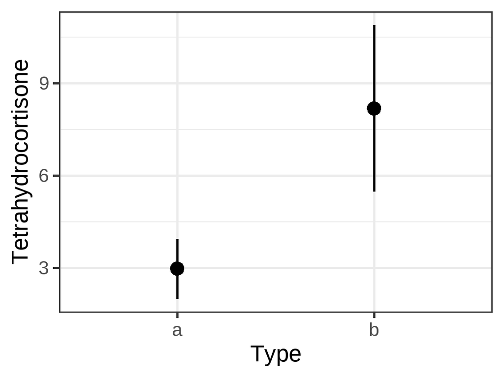

# Пермутационные оценки значимости различий

## Подготовка данных

```r
a <- Cushings$Tetrahydrocortisone[Cushings$Type == 'a']
b <- Cushings$Tetrahydrocortisone[Cushings$Type == 'b']

mean_a <- mean(a)
sd_a <- sd(a)
n_a <- length(a)
se_a <- sd_a/sqrt(n_a)

mean_b <- mean(b)
sd_b <- sd(b)
n_b <- length(b)
se_b <- sd_b/sqrt(n_b)

t_emp <- abs(mean_a - mean_b)/sqrt(se_a^2 + se_b^2)
```

## Пермутация векторов

```r
all_data <- sample(c(a, b))
a_perm <- all_data[1:n_a]
b_perm <- all_data[(n_a + 1):length(all_data)]

mean_a <- mean(a_perm)
sd_a <- sd(a_perm)
n_a <- length(a_perm)
se_a <- sd_a/sqrt(n_a)

mean_b <- mean(b_perm)
sd_b <- sd(b_perm)
n_b <- length(b_perm)
se_b <- sd_b/sqrt(n_b)

t_perm <- abs(mean_a - mean_b)/sqrt(se_a^2 + se_b^2)
```

## Многократные пермутации

```r
t_perm_vector <- rep(NA, 1000)

for(i in 1:999){
    all_data <- sample(c(a, b))
    a_perm <- all_data[1:n_a]
    b_perm <- all_data[(n_a +1):length(all_data)]

    mean_a <- mean(a_perm)
    sd_a <- sd(a_perm)
    n_a <- length(a_perm)
    se_a <- sd_a/sqrt(n_a)

    mean_b <- mean(b_perm)
    sd_b <- sd(b_perm)
    n_b <- length(b_perm)
    se_b <- sd_b/sqrt(n_b)

    t_perm <- abs(mean_a - mean_b)/sqrt(se_a^2 + se_b^2)

    t_perm_vector[i] <-  t_perm
}


  t_perm_vector[1000] <- t_emp
```

## Отображаем графически

```r
t_perm_vector_dataframe <- as.data.frame(t_perm_vector)
ggplot(data=t_perm_vector_dataframe, aes(x=t_perm_vector))+geom_histogram()+geom_vline(xintercept = t_emp, colour = 'red', size = 2)
```

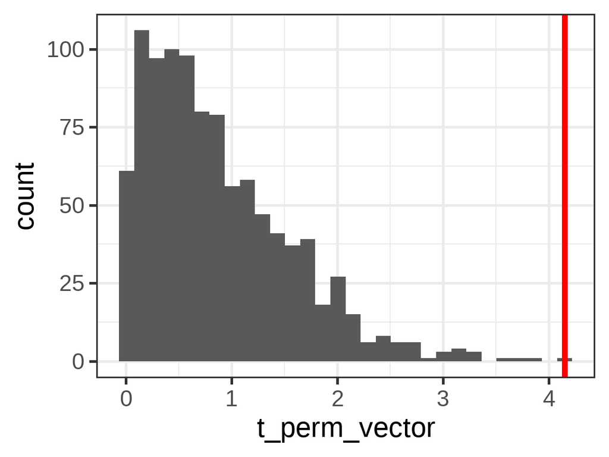

Как часто мы встречаем значение *t*-статистики как для изначальных выборок или больше?

А есть какая-то статистика, которая показывает вероятность встретить такое или более экстремальное значение *t*?…

## Результаты параметрического теста

```r
mean(t_perm_vector >= t_emp) #Доля пермутационных статистик которые больше или равны выборочной статистике
```

```
[1] 0.001
```

```r
tt #Результаты параметрического теста
```

```
    Welch Two Sample t-test

data:  Cushings$Tetrahydrocortisone[Cushings$Type == "a"] and Cushings$Tetrahydrocortisone[Cushings$Type == "b"]
t = -4.1, df = 11, p-value = 0.002
alternative hypothesis: true difference in means is not equal to 0
95 percent confidence interval:
 -7.988 -2.438
sample estimates:
mean of x mean of y
    2.967     8.180
```

# Двухвыборочный t-тест (самостоятельная работа)

## Задание 5

Файл `aml.csv` содержит данные о влиянии регулярной химиотерапии на продолжительность ремиссии.

Прочитаем эти данные

```r
rem <- read.csv(file = "data/aml.csv", header = TRUE)
head(rem)
```

```
  time group
1    9     1
2   13     1
3   13     1
4   18     1
5   23     1
6   28     1
```

- В переменной `time` представлена продолжительность ремиссии в днях.
- `group` указывает, к какой экспериментальной группе принадлежал пациент. В группе 1 проводилась регулярная химиотерапия, в группе 2 - нет.

Ваша задача сравнить эти группы с помощью t-теста.

## Решение: Разведочный анализ

```r
str(rem)
```

```
'data.frame':   23 obs. of  2 variables:
 $ time : int  9 13 13 18 23 28 31 34 45 48 ...
 $ group: int  1 1 1 1 1 1 1 1 1 1 ...
```

```r
# Делаем group фактором
rem$group <- factor(rem$group, labels = c("therapy", "control"))

# Пропущенные значения?
colSums(is.na(rem))
```

```
 time group
    0     0
```

```r
# Объемы выборок?
table(rem$group)
```

```
therapy control
     11      12
```

## Решение: Проверка условий применимости

```r
# Выборки малы, поэтому проверяем на нормальность и отсутствие выбросов
op <- par(mfrow = c(1, 2))
qqPlot(rem$time[rem$group == "therapy"])
```

```
[1] 11  1
```

```r
qqPlot(rem$time[rem$group == "control"])
```

```
[1] 12 11
```

```r
par(op)
```

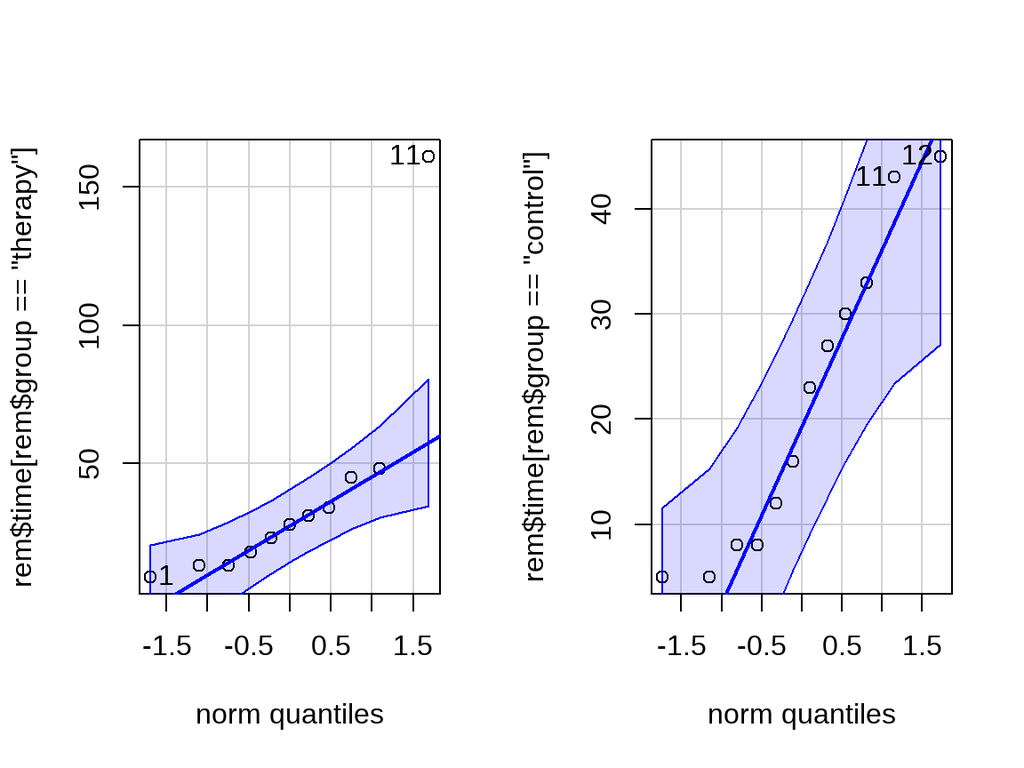

## Решение: Проверка условий применимости

Есть отскакивающее значение в группе `therapy`, в этой группе оно 11 по порядку (видно на `qqPlot()`).

```r
rem$time[rem$group == "therapy"]
```

```
 [1]   9  13  13  18  23  28  31  34  45  48 161
```

```r
rem$time[rem$group == "therapy"][11]
```

```
[1] 161
```

Пусть в этом случае это вполне реальное наблюдение, но это значение придется исключить, т.к. t-тест не устойчив к выбросам.

## Решение: Двухвыборочный t-тест

```r
# удалено наблюдение со значением 161
tt <- t.test(formula = time ~ group, data = rem,
       subset = rem$time != 161)
```

Или то же самое:

```r
# удалено 11 наблюдение в группе `therapy`
tt <- t.test(x = rem$time[rem$group == 'therapy'][-11],
       y = rem$time[rem$group == 'control'])
```

## Решение: Результаты двухвыборочного t-теста

```r
tt
```

```
    Welch Two Sample t-test

data:  rem$time[rem$group == "therapy"][-11] and rem$time[rem$group == "control"]
t = 0.83, df = 20, p-value = 0.4
alternative hypothesis: true difference in means is not equal to 0
95 percent confidence interval:
 -7.486 17.386
sample estimates:
mean of x mean of y
    26.20     21.25
```

## Решение: График со средними и доверительными интервалами

```r
ggplot(data = rem[rem$time != 161, ], aes(x = factor(group), y = time)) +
  stat_summary(fun.data = mean_cl_normal)
```

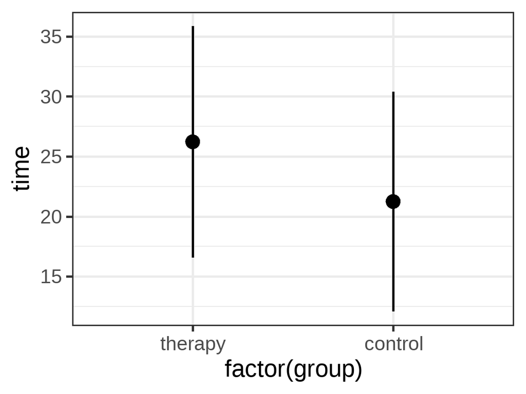

# Парный t-тест (факультативно)

## Пример: Снотворное

В датасете `sleep` содержатся данные об увеличении продолжительности сна по сравнению с контролем после применения двух снотворных препаратов (Cushny, Peebles, 1905, Student, 1908)

Одинаково ли два снотворных влияют на увеличение продолжительности сна?

```r
data(sleep)
head(sleep)
```

```
  extra group ID
1   0.7     1  1
2  -1.6     1  2
3  -0.2     1  3
4  -1.2     1  4
5  -0.1     1  5
6   3.4     1  6
```

```r
# str(sleep)
```

## Проверяем условия применимости…

1. Наблюдения независимы друг от друга?
- Да, независимы. Это случайная выборка людей.
2. Выборки независимы друг от друга?
- **Нет!**. В группах одни и те же люди (10 человек, каждый пил оба снотворных).  
  **ОСТОРОЖНО**. Эти данные НЕ ПОДХОДЯТ для двухвыборочного t-теста, т.к. группы не являются взаимно независимыми. Нужно использовать **парный** t-тест.
3. Объем выборки достаточно велик или величины нормально распределены?
- Объем выборки мал

```r
table(sleep$group)
```

```
 1  2
10 10
```

Нужно проверить форму распределения в обеих группах.

## Нормально ли распределена зависимая переменная в группах?

```r
qqPlot(sleep$extra[sleep$group == 1])
qqPlot(sleep$extra[sleep$group == 2])
```

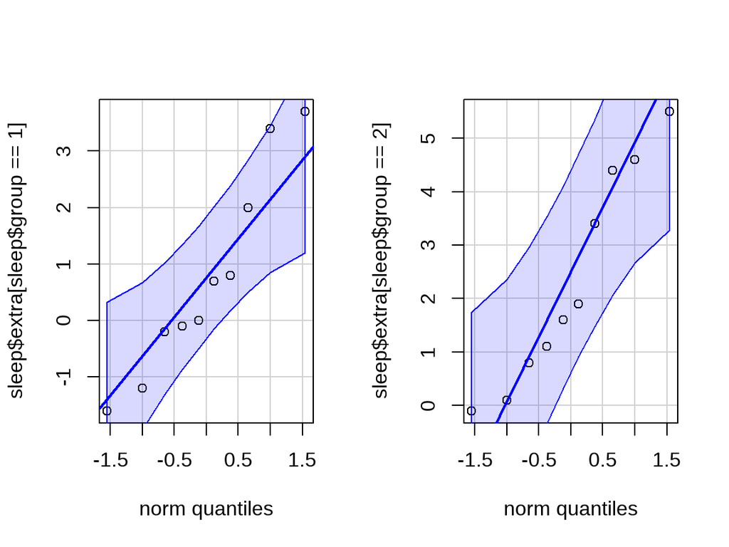

Хорошо. Можно аппроксимировать нормальным распределением

## Парный t-тест в R

Сравним увеличение продолжительности сна при помощи **парного** t-теста.

```r
t.test(sleep$extra[sleep$group == 1], sleep$extra[sleep$group == 2], paired = TRUE)
```

```
    Paired t-test

data:  sleep$extra[sleep$group == 1] and sleep$extra[sleep$group == 2]
t = -4.1, df = 9, p-value = 0.003
alternative hypothesis: true mean difference is not equal to 0
95 percent confidence interval:
 -2.4599 -0.7001
sample estimates:
mean difference
          -1.58
```

## Опишем результаты

```
    Paired t-test

data:  sleep$extra[sleep$group == 1] and sleep$extra[sleep$group == 2]
t = -4.1, df = 9, p-value = 0.003
alternative hypothesis: true mean difference is not equal to 0
95 percent confidence interval:
 -2.4599 -0.7001
sample estimates:
mean difference
          -1.58
```

- Различия изменения продолжительности сна при применении двух препаратов были достоверны ( $t_{9} = -4.06$, $p = <0.01$)

**Кстати, если бы мы не учли зависимость между группами, мы пришли бы к неверному выводу.** В этом можно убедиться, выполнив этот код:

```r
t.test(formula = extra ~ group, data = sleep)
```

## График со средними и доверительными интервалами

```r
ggplot(data = sleep, aes(x = factor(group), y = extra)) +
  stat_summary(fun.data = mean_cl_normal)
```

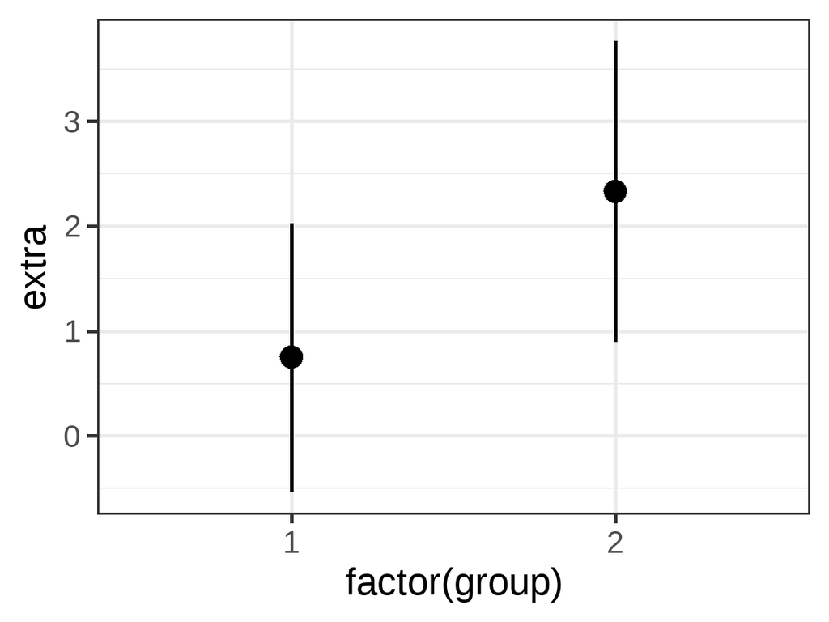

## Take-home messages

- По центральной предельной теореме выборочные средние нормально распределены
  $$\bar X \sim N (\mu, \sigma / \sqrt{n})$$
- Доверительный интервал к среднему значению можно построить из нормального распределения, если известна $\sigma$ в генеральной совокупности, или из $t$-распределения, если она не известна.
- При тестировании нулевой гипотезы оценивают вероятность получения данного или более экстремального значения тестовой статистики при условии, что $H_0$ справедлива. Если эта вероятность меньше выбранного критического уровня значимости, то нулевую гипотезу отвергают.
- Для сравнения выборочных средних лучше использовать t-критерий в модификации Уэлча, который учитывает, что дисперсии в группах могут быть разными.
- Средние в независимых выборках нужно сравнивать двухвыборочным t-тестом.
- Если выборки зависимы — нужно это учесть, поэтому для сравнения средних используется парный t-тест.

## Дополнительные ресурсы

- OpenIntro: Statistics
- Quinn, Keough, 2002
- Sokal, Rohlf, 1995
- Zar, 1999